# Black & White Figures for Print Journals

Daniel Lüdecke

2017-08-04

This document shows examples how to create b/w figures, e.g. if you don’t want colored figures for print-journals.

## Barplots in grey-scaled colors

There are two ways to create plots in black and white or greyscale. For bar plots, `geom.colors = "gs"` creates a plot using a greyscale (based on `scales::grey_pal()`).

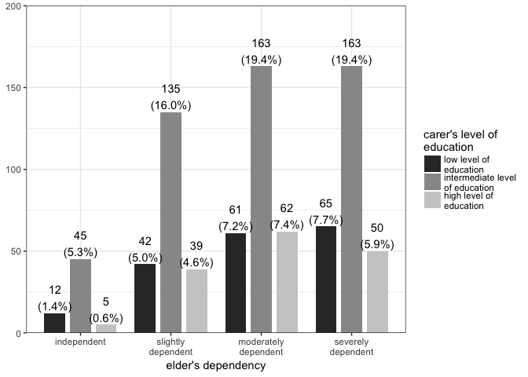

```r
library(sjPlot)
library(sjmisc)
library(sjlabelled)
library(ggplot2)
theme_set(theme_bw())
data(efc)
sjp.grpfrq(efc$e42dep, efc$c172code, geom.colors = "gs")
```

## Lineplots in b/w with different linetypes

Similar to barplots, lineplots can be plotted in greyscale as well (with `geom.colors = "gs"`). However, in most cases lines colored in greyscale are difficult to distinguish. In this case, certain plot types in **sjPlot** support black & white figures with different linetypes.

Following plot-types allow black & white figures:

- `sjp.grpfrq(type = "line")`
- `sjp.int()`
- `sjp.lm(type = "pred")`
- `sjp.glm(type = "pred")`
- `sjp.lmer(type = "pred")`
- `sjp.glmer(type = "pred")`

Use `geom.colors = "bw"` to create a b/w-plot.

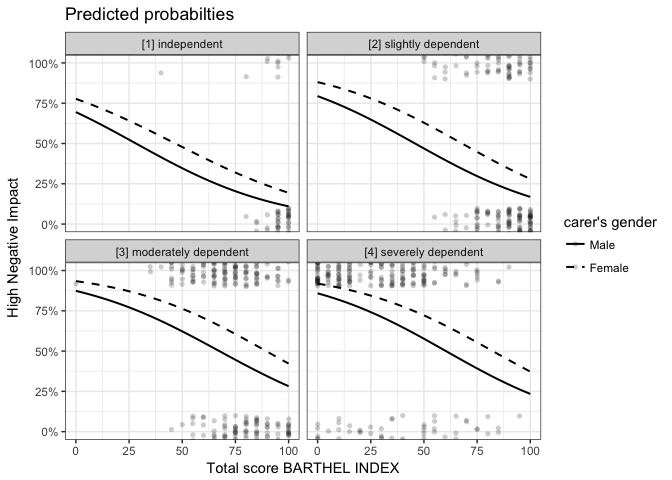

```r
# create binrary response
y <- ifelse(efc$neg_c_7 < median(na.omit(efc$neg_c_7)), 0, 1)
# create data frame for fitting model
df <- data.frame(
  y = to_factor(y),
  sex = to_factor(efc$c161sex),
  dep = to_factor(efc$e42dep),
  barthel = efc$barthtot,
  education = to_factor(efc$c172code)
)
# set variable label for response
set_label(df$y) <- "High Negative Impact"
# fit model
fit <- glm(y ~., data = df, family = binomial(link = "logit"))
# print predicted propbabilities
sjp.glm(fit, type = "pred", vars = c("barthel", "sex","dep"), geom.colors = "bw")
```

Different linetypes do not apply to other linetyped plots (like `sjp.lm(type = "eff")` or `sjp.lm(type = "slope")`), because these usually only plot a single line - so there’s no need for different linetypes, you can just set `geom.colors = "black"` (or `geom.colors = "bw"`).